# Demonstração do pacote *Strucchange*

Author

Rafael Buttini Salviato

## Apresentação

A partir da atividade proposta pelo prof Adalto, vou demonstrar a deteção de quebra estrutural numa série temporal. O banco de dados escolhido foi o BD-usd_ibov_selic_gold, com a série mensal do índice bovespa, taxa selic, USD e Ouro, junto com as suas variações percentuais de jun/95 até mai/20.

## Primeira análise

Aqui, vou deixar a análise de correlação feita para as variáveis do conjunto de dados, que foi feita para o trabalho da disciplina.

```r
setwd("~/Documentos/UFPR/Mestrado - PPGEcon/Disciplinas/ESTATÍSTICA/General/Tarefa de casa")
# Importando os dados
df <- read.csv2("BD-usd_ibov_selic_gold.csv")
df$Data<- as.Date(df$Data,"%d/%m/%y")
df|>str()
```

```
'data.frame':   300 obs. of  9 variables:
 $ Data                  : Date, format: "2020-05-01" "2020-04-01" ...
 $ IndiceBov             : int  87403 80506 73020 104172 113761 115645 108233 107220 104745 101135 ...
 $ Var_percent_IndiceBov : num  8.57 10.25 -29.9 -8.43 -1.63 ...
 $ Selic_taxa_percent    : num  2.92 3.41 4.16 3.54 4.66 4.53 4.66 5.91 5.66 6.17 ...
 $ Var_percent_Selic_taxa: num  -14.37 -18.03 17.51 -24.03 2.87 ...
 $ USD                   : num  5.64 5.33 4.88 4.34 4.15 4.11 4.16 4.09 4.12 4.02 ...
 $ Var_percent_USD       : num  5.82 9.22 12.44 4.58 0.97 ...
 $ Ouro                  : num  294 295 270 232 218 ...
 $ Var_percent_Ouro      : num  -0.54 9.33 16.19 6.37 6.53 ...
```

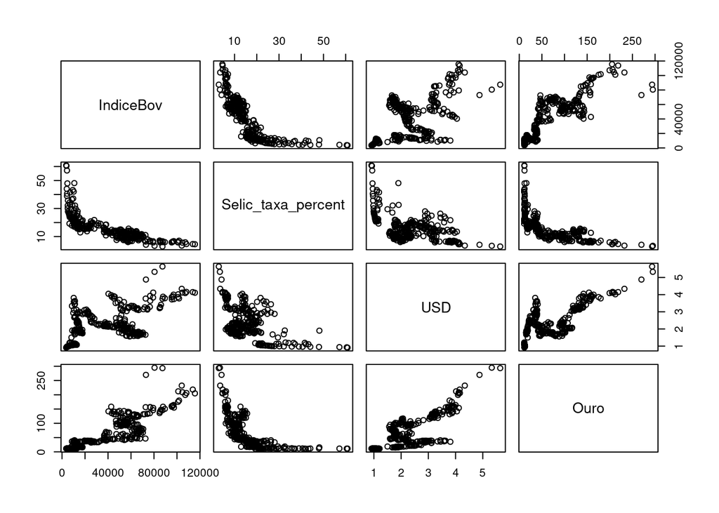

```r
plot(df[,c("IndiceBov", "Selic_taxa_percent", "USD", "Ouro")])
```

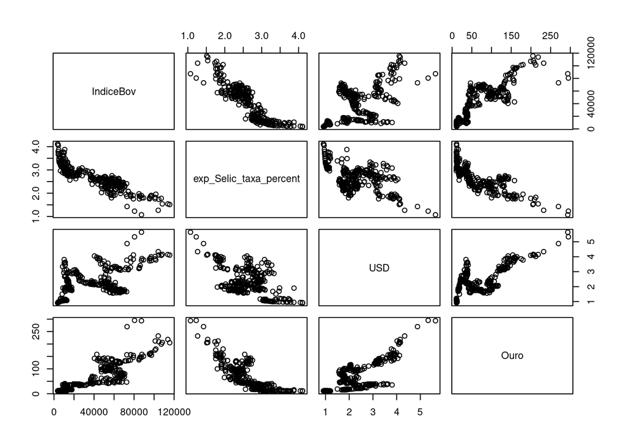

```r
df["exp_Selic_taxa_percent"]=log(df["Selic_taxa_percent"])
plot(df[,c("IndiceBov", "exp_Selic_taxa_percent", "USD", "Ouro")])
```

Beleza, vamos montar um correlograma com as variáveis IndiceBov, Selic_taxa_percent, USD e Ouro.

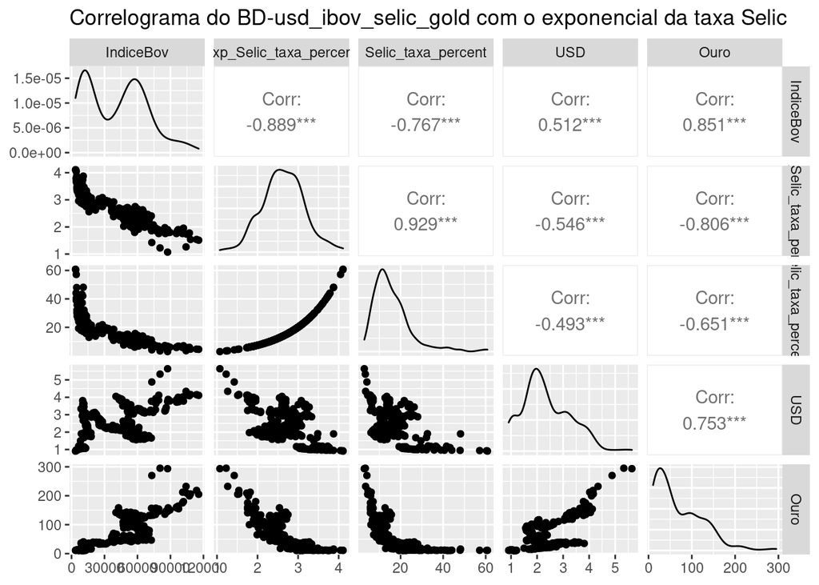

```r
#install.packages("GGally")

# Quick display of two cabapilities of GGally, to assess the distribution and correlation of variables
library(GGally)


# Check correlations (as scatterplots), distribution and print corrleation coefficient
ggpairs(df[,c("IndiceBov",
              "exp_Selic_taxa_percent",
              "Selic_taxa_percent",
              "USD",
              "Ouro")],
        title="Correlograma do BD-usd_ibov_selic_gold com o exponencial da taxa Selic",
        progress = FALSE)
```

## Segunda análise

Vamos analisar o índice Ibovespa ao longo do tempo.

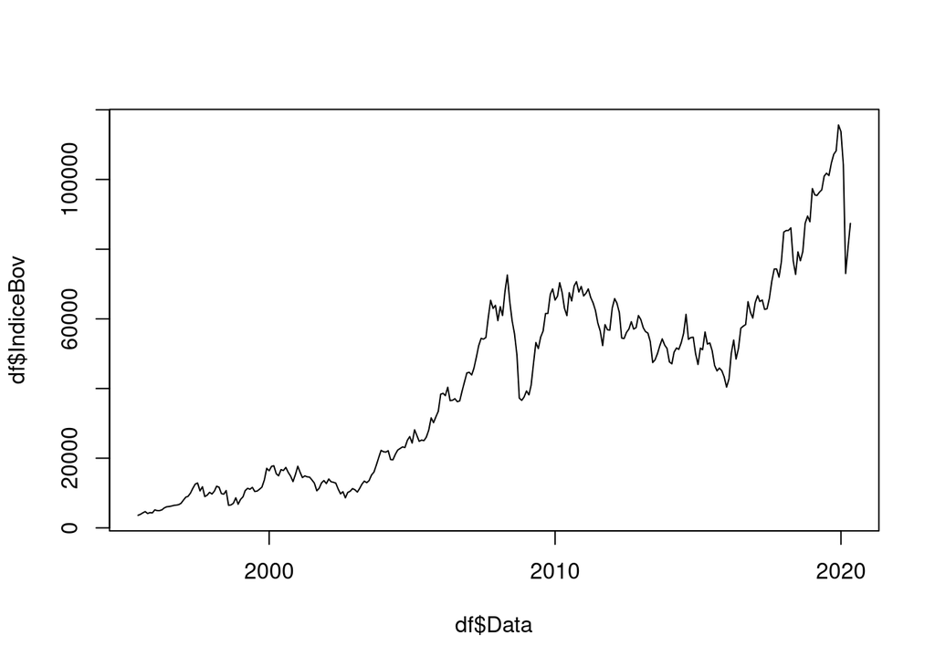

```r
plot(df$Data,df$IndiceBov, type="l")
```

O pacote [strucchange](https://cran.r-project.org/web//packages/strucchangeRcpp/vignettes/strucchange-intro.pdf) disponibiliza ferramentas para detectarmos quebras estruturais em modelos de regressão. Num contexto de séries temporais, podemos pensar num modelo de regressão linear simples para representar o componente de tendência da série. Com isso, vamos utilizar a função [breakpoint](https://www.rdocumentation.org/packages/strucchange/versions/1.5-3/topics/breakpoints) para nos dizer quantos e quais pontos de quebra temos na série do “IndiceBov”:

```r
#install.packages("strucchange")
library(strucchange)
#df$Data|>min()
ts_data <- ts(df$IndiceBov, start=c(1995, 6), frequency=12)
breakpoints(ts_data~1)
```

```
     Optimal 5-segment partition:

Call:
breakpoints.formula(formula = ts_data ~ 1)

Breakpoints at observation number:
45 90 158 203

Corresponding to breakdates:
1999(2) 2002(11) 2008(7) 2012(4)
```

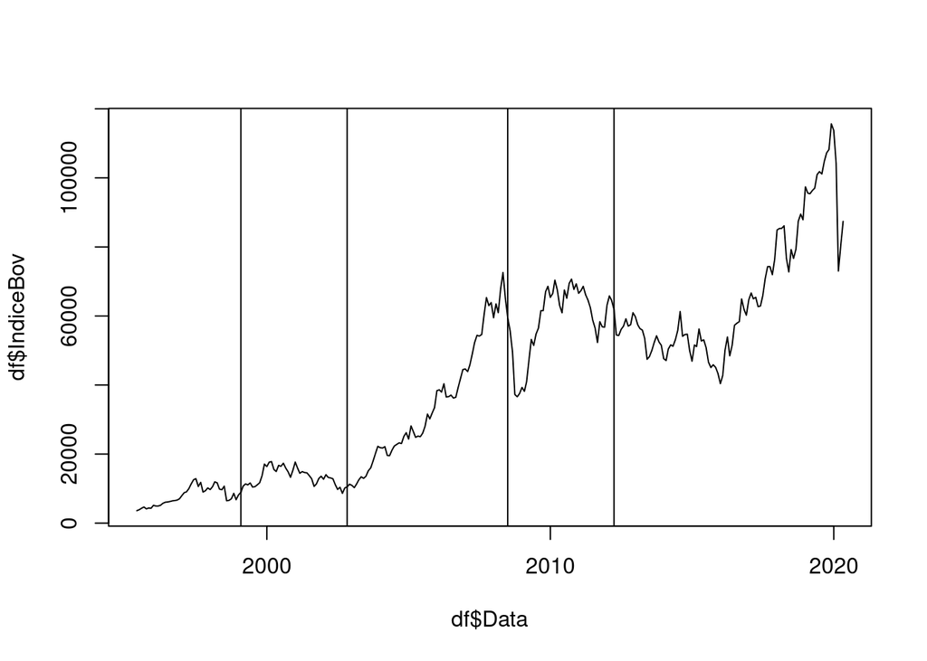

```r
bp <- breakpoints(ts_data~1)

datas_das_quebras <- sort(df$Data)[bp$breakpoints]
plot(df$Data,df$IndiceBov, type="l")
sapply(datas_das_quebras,
       function(x){
         abline(v=x)
       })
```

```r
df$quebra_1 <- sapply(df$Data,
       function(x){
         ifelse(x<datas_das_quebras[1],
                0,1)
       })

df$quebra_2 <- sapply(df$Data,
       function(x){
         ifelse(x<datas_das_quebras[2],
                0,1)
       })

df$quebra_3 <- sapply(df$Data,
       function(x){
         ifelse(x<datas_das_quebras[3],
                0,1)
       })

df$quebra_4 <- sapply(df$Data,
       function(x){
         ifelse(x<datas_das_quebras[4],
                0,1)
       })

m1=lm(IndiceBov~exp_Selic_taxa_percent+
     USD+
     Ouro+
     quebra_1+
     quebra_2+
     quebra_3+
     quebra_4, data=df)
m1|>summary()
```

```
Call:
lm(formula = IndiceBov ~ exp_Selic_taxa_percent + USD + Ouro +
    quebra_1 + quebra_2 + quebra_3 + quebra_4, data = df)

Residuals:
   Min     1Q Median     3Q    Max
-42742  -4556   -862   4517  24239

Coefficients:
                        Estimate Std. Error t value Pr(>|t|)
(Intercept)             78918.40    7001.88  11.271  < 2e-16 ***
exp_Selic_taxa_percent -19276.41    2105.84  -9.154  < 2e-16 ***
USD                     -9886.90    1346.41  -7.343 2.09e-12 ***
Ouro                      377.24      35.07  10.758  < 2e-16 ***
quebra_1                 5219.60    2585.42   2.019 0.044415 *
quebra_2                12664.60    1741.70   7.271 3.28e-12 ***
quebra_3                -1556.70    2320.06  -0.671 0.502767
quebra_4                -6974.25    2088.09  -3.340 0.000947 ***
---
Signif. codes:  0 '***' 0.001 '**' 0.01 '*' 0.05 '.' 0.1 ' ' 1

Residual standard error: 8794 on 292 degrees of freedom
Multiple R-squared:  0.8993,    Adjusted R-squared:  0.8969
F-statistic: 372.6 on 7 and 292 DF,  p-value: < 2.2e-16
```

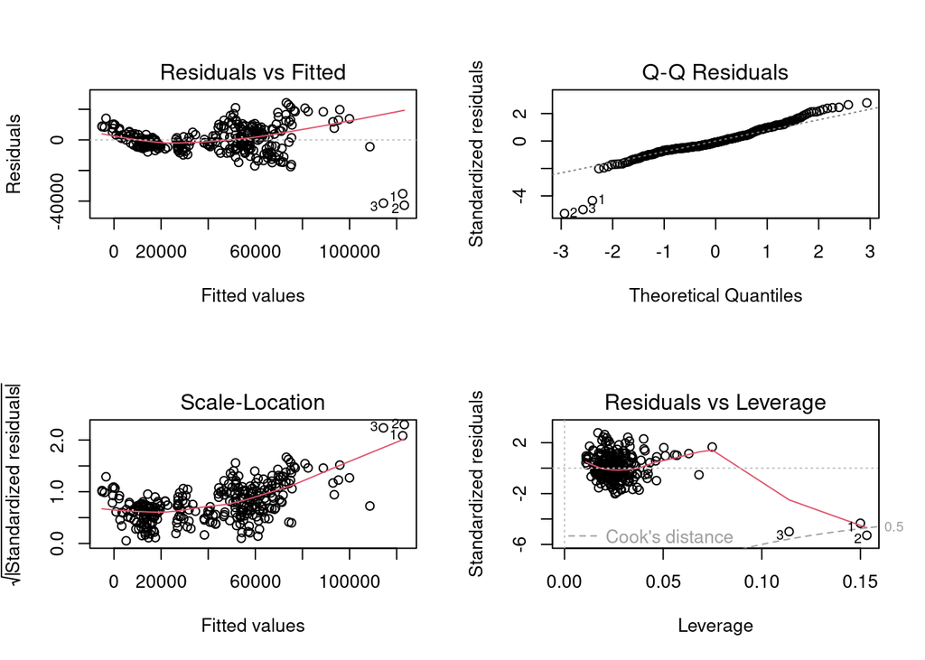

```r
par(mfrow=c(2,2))
m1|>plot()
```

E pronto! Bom, do modelo ajustado podemos descartar a “quebra_3” pois esta não foi significativa para o modelo (i.e: p-valor de 50%, então o IC de 95% da variável contem o valor zero). Também, é válido a inclusão de variáveis de interação (e.g: “Ouro*quebra1”) para melhorar a predição do modelo.

Outro ponto, faz sentido remover as observações 1, 2 e 3, referentes ao começo do ano de 2020. Sabemos que de fato, este é o começo do período pandêmico, então o comportamento fica um pouco desajustado se temos apenas poucas observações. Fato que, nos gráficos de diagnóstico, são estes pontos que acabam “quebrando” o modelo.